# RMarkdown Assignment

Caio Faro

January 20, 2016

## *Content*

I’m interested in fishery management and ocean conservation, particulary related to ecologically sensitive species such as **sharks and rays**. Currently I’m working in the [Fisheries Management](https://github.com/fishmgt) group for the Informatics course at the Master of Environmental Science and Management at UCSB.

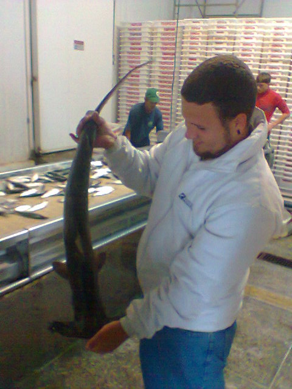

## *Techniques*

I hope to take from the Informatics course skills like how use the github plataform, that allows a collaborative workspace, and how to organize and manage data. Also, I think improving my R skills, especially in generating better visualitions of data, might be a differential in my future professional life.

## *Data*

At the present moment I’m not participating in any MESM project. However, when searching for a opportunity to write my proposal I looked at The International Comission for the Conservation of Atlantic Tunas (ICCAT) database on shark captures, which I’ll be using for this assignment.

```r
# read csv
d = read.csv('data/caio-faro_ICCATSharks.csv')
Brazil <- subset(d, PartyName == "BRAZIL")

summary(Brazil)
```

```
##     Species                     ScieName              SpeciesGrp
##  BSH    :211   Prionace glauca      :211   4-Sharks (major):403
##  SMA    :191   Isurus oxyrinchus    :191   5-Sharks (other):821
##  SPN    :133   Sphyrna spp          :133
##  BTH    :130   Alopias superciliosus:130
##  SHX    : 92   Squaliformes         : 92
##  RSK    : 85   Carcharhinidae       : 85
##  (Other):382   (Other)              :382
##      YearC          Decade     Status        PartyName           Flag
##  Min.   :1994   Min.   :1990   CP :1224   BRAZIL  :1224   Brazil   :1224
##  1st Qu.:2003   1st Qu.:2000   NCC:   0   ALGÉRIE :   0   Algerie  :   0
##  Median :2005   Median :2000   NCO:   0   ANGOLA  :   0   Angola   :   0
##  Mean   :2006   Mean   :2002              BARBADOS:   0   Argentina:   0
##  3rd Qu.:2009   3rd Qu.:2000              BELIZE  :   0   Barbados :   0
##  Max.   :2014   Max.   :2010              CANADA  :   0   Belize   :   0
##                                           (Other) :   0   (Other)  :   0
##              Fleet     Stock        SampArea        AreaT1
##  BRA-BRA-ITAJAI :138   A+M:821   unkn   :1213   SW     :1206
##  BRA-BRA-NATAL  :114   ATN:  6   BIL96  :  11   NW     :  17
##  BRA-BRA-RJANERO: 92   ATS:397   BIL91  :   0   GOFM   :   1
##  BRA            : 67   MED:  0   BIL92  :   0   ATL    :   0
##  BRA-BRA-SANTOS : 64             BIL93  :   0   AZOR   :   0
##  BRA-ESP-NATAL  : 60             BIL94  :   0   BLACK  :   0
##  (Other)        :689             (Other):   0   (Other):   0
##        SpcGearGrp     GearGrp       GearCode   CatchTypeCode
##  All gears  :822   LL     :998   LL     :839   C :977
##  Longline   :330   UN     : 77   LLFB   :137   DD: 13
##  Other surf.: 72   BB     : 46   UNCL   : 77   L :234
##                    SU     : 36   BB     : 46
##                    HL     : 35   SURF   : 36
##                    PS     : 19   HAND   : 35
##                    (Other): 13   (Other): 54
##   QualInfoCode      Qty_t
##  RPT1   :1158   Min.   :   0.000
##  UNKN   :  47   1st Qu.:   0.300
##  RCSP   :  19   Median :   3.366
##  OBSH   :   0   Mean   :  56.081
##  RCAR   :   0   3rd Qu.:  21.776
##  RCGR   :   0   Max.   :2609.500
##  (Other):   0
```

## *Data Wrangling*

```r
suppressWarnings(suppressMessages(require(readr)))
suppressWarnings(suppressMessages(require(dplyr)))

tbl_df(Brazil)
```

```
## Source: local data frame [1,224 x 18]
##
##    Species                 ScieName       SpeciesGrp YearC Decade Status
##     (fctr)                   (fctr)           (fctr) (int)  (int) (fctr)
## 1      BSH          Prionace glauca 4-Sharks (major)  2002   2000     CP
## 2      SMA        Isurus oxyrinchus 4-Sharks (major)  2002   2000     CP
## 3      SHX             Squaliformes 5-Sharks (other)  2002   2000     CP
## 4      BSH          Prionace glauca 4-Sharks (major)  2002   2000     CP
## 5      FAL Carcharhinus falciformis 5-Sharks (other)  2002   2000     CP
## 6      BTH    Alopias superciliosus 5-Sharks (other)  2002   2000     CP
## 7      SMA        Isurus oxyrinchus 4-Sharks (major)  2002   2000     CP
## 8      SHX             Squaliformes 5-Sharks (other)  2002   2000     CP
## 9      BSH          Prionace glauca 4-Sharks (major)  2002   2000     CP
## 10     FAL Carcharhinus falciformis 5-Sharks (other)  2002   2000     CP
## ..     ...                      ...              ...   ...    ...    ...
## Variables not shown: PartyName (fctr), Flag (fctr), Fleet (fctr), Stock
##   (fctr), SampArea (fctr), AreaT1 (fctr), SpcGearGrp (fctr), GearGrp
##   (fctr), GearCode (fctr), CatchTypeCode (fctr), QualInfoCode (fctr),
##   Qty_t (dbl)
```

```r
Brazil %>%
  select(ScieName, YearC, Status, Fleet, Stock, GearCode, Qty_t) %>%
  group_by(ScieName) %>%
  summarize(Total_Catch_t = sum(Qty_t))
```

```
## Source: local data frame [27 x 2]
##
##                    ScieName Total_Catch_t
##                      (fctr)         (dbl)
## 1               Alopias spp    148.827000
## 2     Alopias superciliosus    747.963952
## 3            Carcharhinidae   1600.884882
## 4         Carcharhiniformes   6132.138284
## 5  Carcharhinus falciformis   1811.366600
## 6       Carcharhinus leucas      8.237015
## 7   Carcharhinus longimanus   2155.981042
## 8     Carcharhinus signatus     23.374000
## 9         Carcharias taurus      9.272000
## 10       Coastal Sharks nei    411.040000
## ..                      ...           ...
```

## 4. Answers and Taks

**Task**. Convert the following table [CO<sub>2</sub> emissions per country since 1970](http://edgar.jrc.ec.europa.eu/overview.php?v=CO2ts1990-2014&sort=des9) from wide to long format and output the first few rows into your Rmarkdown. I recommend consulting `?gather` and you should have 3 columns in your output.

```r
library(dplyr)
library(readxl) # install.packages('readxl')

# xls downloaded from http://edgar.jrc.ec.europa.eu/news_docs/CO2_1970-2014_dataset_of_CO2_report_2015.xls
xls = '../data/co2_europa.xls'

require(tidyr)
require(dplyr)

print(getwd())
co2 <- read_excel(xls, skip=12)
Longco2 <- gather(co2, "Year", "Emissions", -Country) %>%
  mutate(Year = as.numeric(Year))

head(Longco2)
```

[output not shown]

**Question**. Why use `skip=12` argument in `read_excel()`? Because the first 12 rows are metadata and we skip them to read only the data from the table we’re gonna use.

**Task**. Report the top 5 emitting countries (not World or EU28) for 2014 using your long format table. (You may need to convert your year column from factor to numeric, eg `mutate(year = as.numeric(as.character(year)))`. As with most analyses, there are multiple ways to do this. I used the following functions: `filter`, `arrange`, `desc`, `head`).

```r
Top5 <- Longco2 %>%
    filter(Year == 2014, Country != "World", Country != "EU28") %>%
    arrange(desc(Emissions))

head(Top5, n=5)
```

[output not shown]

**Task**. Summarize the total emissions by country (not World or EU28) across years from your long format table and return the top 5 emitting countries. (As with most analyses, there are multiple ways to do this. I used the following functions: `filter`, `arrange`, `desc`, `head`).

```r
SumCountries <- Longco2 %>%
              filter(Country != "World", Country != "EU28") %>%
              group_by(Country) %>%
              summarise(TotalEmission = sum(Emissions)) %>%
              arrange(desc(TotalEmission))

head(SumCountries)
```

[output not shown]